# Relatório Técnico: Gráfico Animado

Author

Milena Paz, Kailany Aline

Published

March 19, 2025

# Resumo

Este relatório apresenta a construção de um gráfico animado desenvolvido em R utilizando os pacotes ggplot2 (WICKHAM, 2016) e gganimate(PEDERSEN; ROBINSON, 2024) . A animação permite visualizar a variação da temperatura global ao longo dos meses para diferentes anos, tornando a análise mais acessível e intuitiva. Para garantir maior usabilidade e acessibilidade, foi adotada uma paleta de cores adaptada para daltônicos, seguindo diretrizes de visualização inclusiva, com o auxílio do pacote RColorBrewer. O objetivo é que o gráfico possa ser interpretado corretamente por um público mais amplo, incluindo pessoas com diferentes tipos de deficiência visual relacionada à percepção de cores.

O gráfico é salvo como um arquivo .gif, compatível com a maioria dos navegadores modernos. A construção do gráfico envolveu desafios como a ordenação correta dos meses, a conexão entre os anos para criar uma linha contínua e a escolha de cores acessíveis. Apesar dessas dificuldades, o resultado final proporciona uma representação clara e dinâmica das tendências de temperatura ao longo do tempo.

# Metodologia

Os dados utilizados nesta animação foram obtidos a partir do site da NASA, na seção “Tables of Global and Hemispheric Monthly Means and Zonal Annual Means”. Essa base apresenta a variação de temperatura global, do hemisfério norte, hemisfério sul e por zonas. O primeiro conjunto de dados, global, é o que nos interessa. Os dados são disponibilizados nos formatos .csv e .txt e contêm informações mensais sobre anomalias de temperatura em relação à média histórica.

Antes da construção do gráfico, realizamos alguns procedimentos essenciais para garantir a integridade e a correta estruturação dos dados:

- Remoção de linhas iniciais não estruturadas: O arquivo contém metadados e informações explicativas nas primeiras linhas, que foram descartadas durante a importação.
- Tratamento de valores ausentes: Alguns registros utilizam *** para representar dados faltantes. Esses valores foram convertidos para NA, evitando distorções na visualização.

A construção da animação foi inspirada nas representações gráficas de Ed Hawkins (HAWKINS; FÆHN; FUGLESTVEDT, 2019) e nas animações divulgadas pela NASA(SCIENTIFIC VISUALIZATION STUDIO, 2023) , que buscam tornar a comunicação científica sobre mudanças climáticas mais acessível e impactante. Uma importante referência foram os vídeos e postagens de Riffomonas (SCHLOSS, 2022), que passou pelas mesmas dificuldades ao montar uma espiral climática.

# Codificação da Animação

```r
##LENDO E ORGANIZANDO OS DADOS
 #GLB.Ts+dSST.csv foi baixado na URL abaixo
 #
 raws <- read.csv("GLB.Ts+dSST.csv", na="***",skip=1) |>
         subset(select=1:13)
 #vamos usar os nomes dos meses em português
 meses<-c("Jan","Fev","Mar","Abr","Mai","Jun","Jul","Ago",
          "Set","Out","Nov","Dez")
 #para poder criar o grafico precisamos agrupar por ano e categorizar por mes:
 temps<- data.frame(Ano=rep(raws$Year, times=12),
               Mes=rep(meses, each=146),
               temp=unlist(raws[-1]))
 rownames(temps) <- NULL


 #começaremos criando um grafico estático
 library(gganimate) #carrega o ggplot2 automaticamente

 #### Versão inicial ####
 temps|> ggplot(aes(x=Mes,y=temp,group=Ano,color=Ano)) +
   geom_line(show.legend = F) +
   coord_radial()
 #temos alguns problemas com essa versao inicial:
 # 1. os meses estao desorganizados (ordem alfabetica, que nao é o certo)
 # 2. a posicao dos meses deve começar no meio-dia
 # 3. as linhas nao se conectam

 # PROBLEMA 1: ----
 #para resolver isso teremos que organizar os meses na ordem certa
 #um método seria transformar a variavel Mes em FATOR:
 temps$Mes<- factor(temps$Mes, levels=meses)
 str(temps$Mes)
 #repetindo o mesmo codigo
 ggplot(temps, aes(x=Mes,y=temp,group=Ano,color=Ano)) +
   geom_line(show.legend = F) +
   coord_radial()
 #resolvido!

 # PROBLEMA 2: ----
 #Para resolver isso é só usar um argumento de coord_radial(start)
 ggplot(temps,aes(x=Mes,y=temp,group=Ano,color=Ano)) +
   geom_line(show.legend = F) +
   coord_radial(start=pi/6)
 #ta meio ruim de ler porque ficou sobreposto, depois mexemos nisso

 # PROBLEMA 3: ----
 # aqui vai precisar de uma gambiarra; porque queremos que o valor de dezembro
 #conecte com o janeiro do próximo ano, para que seja uma linha contínua
 proxJan <- dplyr::filter(temps,Mes == "Jan")
 proxJan$Ano <- proxJan$Ano - 1
 proxJan$Ano[1]<-NA
 proxJan$Mes <- "proxJan"
 t.dados <-rbind(temps,proxJan)
 t.dados$numMes <- as.numeric(t.dados$Mes)
 #ai a gente vai ter q fazer manualmente os rotulos e a escala
 t.dados |> ggplot(aes(x=numMes,y=temp,group=Ano,color=Ano)) + #mudança no aes(x=)
   geom_line(show.legend = F) +
   scale_x_continuous(breaks=1:12,labels=meses,expand = c(0,0))+
   #aproveitando pra deixar um espaço no centro
   scale_y_continuous(limits = c(-2, 2.7),expand = c(0,0)) +
   coord_radial()
 #com essa mudança, o argumento start nao e necessario para que o plot fique centrado
 #na posicao meio-dia
 #ok, agora ta tudo conectado! fonte da gambiarra: https://youtu.be/NYF9ySYSvwQ

 #### Versão melhorada ####

 # Escala
 escala<- data.frame(x=c(1.55,1.37,1.35),xend=c(12.45,12.63,12.65),y=c(0,1.5,2),yend=c(0,1.5,2))
 ##
 t.dados|> ggplot(aes(x=numMes,y=temp,group=Ano,color=Ano)) +
   geom_line(show.legend = F,linewidth=0.8) + #linhas mais grossas
   scale_x_continuous(breaks=1:12,labels=meses,expand = c(0,0))+
   scale_y_continuous(limits = c(-1.5, 2.7),expand = c(0,0)) +
   coord_radial() +
   #mudando as cores para uma paleta divergente e colorblind-friendly
   #do pacote rColorBrewer
   scale_color_distiller(palette="RdYlBu") +
   #desenha linhas indicando a escala (0, 1.5 e 2 graus celsius)
   geom_segment(data=escala,aes(x=x,xend=xend,y=y,yend=yend),
                color=c("slateblue4","aliceblue","aliceblue"),inherit.aes = F)+
   #texto para enumerar a escala
   annotate("text",x=1,y=c(1.5,2,0),label=c("1.5°C","2°C","0°C"),
            color=c("aliceblue","aliceblue","slateblue4"), size=4.5)+
   #remove os nomes dos eixos (nao faz sentido ter) e aqueles tracinhos da escala
   theme(
     panel.background = element_rect(fill="black"),
     plot.background = element_rect(fill="#6C708F",color="#6C708F"),
     panel.grid = element_blank(),
     axis.ticks = element_blank(),
     axis.text.x = element_text(color="white",size=18),
     axis.text.y = element_blank(),
     axis.title.x= element_blank(),
     axis.title.y = element_blank()
   )
 #salva a forma estatica
 ggsave("espiral.png",width=5,height=5,units="in",dpi=250)

 #daqui em diante é só animar:
 #### Versão final e animada ####
 bleb<-t.dados|> ggplot(aes(x=numMes,y=temp,group=Ano,color=Ano)) +
   geom_line(show.legend = F,linewidth=.8) +
   scale_x_continuous(breaks=1:12,labels=meses,expand = c(0,0))+
   scale_y_continuous(limits = c(-2, 2.7),expand = c(0,0)) +
   coord_radial() +
   scale_color_distiller(palette="RdYlBu") +
   geom_segment(data=escala,aes(x=x,xend=xend,y=y,yend=yend),
                color=c("slateblue4","aliceblue","aliceblue"),inherit.aes = F)+
   annotate("text",x=1,y=c(1.5,2,0),label=c("1.5°C","2°C","0°C"),
            color=c("aliceblue","aliceblue","slateblue4"), size=4.5)+
   #escreve o ano no centro do vão que deixei no centro lá no PROBLEMA 3
   geom_label(aes(x = 12, y=-2, label = Ano),label.size=0, label.padding=unit(10,"pt"),
              size=6,color="white",fill="grey5")+
   theme(
     panel.background = element_rect(fill="grey5"),
     plot.background = element_rect(fill = "#6C708F",color="#6C708F"),
     panel.grid = element_blank(),
     axis.ticks = element_blank(),
     axis.text.x = element_text(color="white",size=18),
     axis.text.y = element_blank(),
     axis.title.x= element_blank(),
     axis.title.y = element_blank()
   )+
   transition_manual(frames = Ano, cumulative = T)

 anim_save("espiral2.gif",
           animation=animate(bleb,height = 5,width = 5, units = "in",
                             res = 250,bg = 'transparent',nframes=146,end_pause=20))

## Como a animação demora MUITO para renderizar, fazer isso em tempo real se torna inviável com
## a tecnologia usada. Até onde vi, isso parece ser causado principalmente pelo geom_label()
## indicando o ano do frame atual. Uma possível solução seria simplesmente não mostrar
## o ano atual no gráfico, mas isso retira uma importante informação da animação
```

# Resultado da Aplicação

A animação gerada evidencia a evolução das anomalias de temperatura ao longo do tempo, mostrando um rápido aumento nos anos mais recentes e reforçando a tendência de aquecimento global. A disposição radial facilita a identificação de padrões sazonais e a comparação entre diferentes períodos, destacando tendências de curto e longo prazo.

A seguir, apresentamos a versão mais recente do gráfico animado gerado com os dados fornecidos.

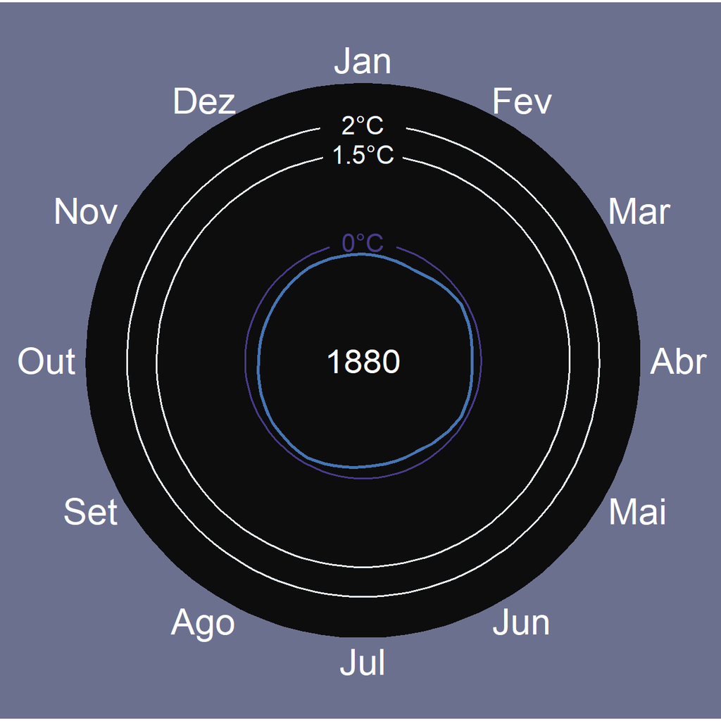

Gráfico Animado